# AEscala de Percepção Social do Uso de Drogas

Este relatório objetiva apresentar as análises introdutória do instrumento “Escala de percepção social do uso de drogas’’, que está em fase de desenvolvimento pelo Centro de Referência em Pesquisa, Intervenção e Avaliação em Álcool e Outras Drogas (http://www.ufjf.br/crepeia/).

O instrumento está sendo validado para população de educadores. O objetivo da pesquisa é oferecer uma medida confiável para avaliação da percepção social de educadores de um curso à distância oferecido pela Secretaria Nacional de Políticas sobre Drogas para aproximadamente 10.000 educadores dos estados de Minas Gerais, Rio de Janeiro e Paraná.

Durante todo o processo de desenvolvimento, foram utilizadas ferramentas de código-aberto, para facilitar o re-uso das técnicas e procedimentos desenvolvidos. Todo conteúdo do instrumento e de suas etapas estará disponível para o público no repositório (http://github.com/crepeia/ead-senad).

Neste relatório são apresentadas, análises da escala com base em uma amostra de 2766 educadores do curso. As análises foram conduzidas através da linguagem de programação R usando os pacotes *car* e *psych*.

## Banco de Dados

O banco de dados da pesquisa, pode ser obtido no seguinte endereço: (https://github.com/crepeia/ead-senad/blob/master/percepcaosocial_df.csv).

## Resultados

Os resultados são apresentados por tópicos: caracterização da amostra, avaliação descritiva da escala e análise fatorial exploratória.

### Bibliotecas

```r
# Load packages
library(car)      # Load packge - used function Recode
library(psych)    # Load packge - used for EFA
library(mirt)     # CFA
library(xtable)   # Load xtable package

# Read data
attitudesDf  <- read.csv("atitudesEducadores_df.csv")

# Convert into scale items into numeric
for (i in 33:71) {
  attitudesDf[,i] <- recode(attitudesDf[,i], "'Discordo totalmente'=1;'Discordo'=2;'Nem discordo, nem concordo'=3;'Concordo'=4;'Concordo totalmente'=5")
  attitudesDf[,i] <- as.numeric(attitudesDf[,i])
}

## Create variable - sum scales to remove NA's
attitudesDf$scaleSum  <- rowSums(attitudesDf[,33:71])
```

### Participantes que recusaram

#### Termo consentimento

```r
table(attitudesDf$termo=="Sim", useNA = "always")
```

```
##
## FALSE  TRUE  <NA>
##    91  2953   234
```

```r
# Porcentagem de recusas
325/(2953+325)*100
```

```
## [1] 9.914582
```

```r
## Subset consented participation
attitudesDf  <- subset(attitudesDf, subset=attitudesDf$termo=="Sim")
```

#### Não preencheram toda a escala

```r
# Table with complete cases
table(!is.na(attitudesDf$scaleSum), useNA="always")
```

```
##
## FALSE  TRUE  <NA>
##   187  2766     0
```

```r
187/(187+2766)*100
```

```
## [1] 6.332543
```

```r
## Subset completed observations
attitudesDf  <- subset(attitudesDf, subset=!is.na(attitudesDf$scaleSum))
```

A porcentagem de pessoas que não preencheram toda a escala foi de 6.33%

### Sócio-demográficas

#### Idade

```r
attitudesDf$idade  <- as.numeric(as.character(attitudesDf$idade))
attitudesDf$idade[attitudesDf$idade < 18 | attitudesDf$idade > 68 ]  <- NA
summary(attitudesDf$idade) # all
```

```
##    Min. 1st Qu.  Median    Mean 3rd Qu.    Max.    NA's
##   18.00   34.00   40.00   40.59   47.00   68.00     284
```

```r
by(attitudesDf$idade, attitudesDf$sexo, describe) # by sex
```

```
## attitudesDf$sexo: Feminino
##   vars    n  mean   sd median trimmed   mad min max range skew kurtosis
## 1    1 2120 40.74 8.68     41   40.65 10.38  20  68    48 0.08    -0.67
##     se
## 1 0.19
## --------------------------------------------------------
## attitudesDf$sexo: Masculino
##   vars   n  mean   sd median trimmed   mad min max range skew kurtosis
## 1    1 358 39.82 9.74     39   39.34 10.38  18  67    49 0.39    -0.44
##     se
## 1 0.51
```

#### Sexo

```r
cbind(round(prop.table(sort(table(attitudesDf$sexo), decreasing = TRUE)),2))
```

```
##           [,1]
## Feminino  0.86
## Masculino 0.14
```

#### Escolaridade

```r
cbind(round(prop.table(sort(table(attitudesDf$escolaridade), decreasing = TRUE)),2))
```

```
##                               [,1]
## Pós-graduação                 0.64
## Ensino Superior Completo      0.29
## Ensino Superior Incompleto    0.05
## Ensino Médio Completo         0.01
## Ensino Fundamental Completo   0.00
## Ensino Médio Incompleto       0.00
## Ensino Fundamental Incompleto 0.00
```

#### Estado Civil

```r
cbind(round(prop.table(sort(table(attitudesDf$estadocivil), decreasing = TRUE)),2))
```

```
##                [,1]
## Casado (a)     0.59
## Solteiro (a)   0.21
## Divorciado (a) 0.09
## União Estável  0.08
## Viúvo (a)      0.02
## Outros         0.01
```

#### Tempo de serviço

```r
timeWorking  <- as.numeric(as.character(attitudesDf$tempodeservico))
timeWorking[timeWorking > 59]  <- NA
summary(timeWorking)
```

```
##    Min. 1st Qu.  Median    Mean 3rd Qu.    Max.    NA's
##    0.00    5.00   12.00   12.85   20.00   59.00     544
```

#### Religião

```r
cbind(round(prop.table(sort(table(attitudesDf$religiao), decreasing = TRUE)),2))
```

```
##              [,1]
## Católica     0.66
## Evangélica   0.19
## Espírita     0.08
## Sem religião 0.04
## Outras       0.02
## Umbanda      0.00
## Budismo      0.00
## Candomblé    0.00
```

#### Contato com o tema

```r
cbind(round(prop.table(sort(table(attitudesDf$contatoanterior), decreasing = TRUE)),2))
```

```
##     [,1]
## Sim 0.62
## Não 0.38
```

#### Lida com

```r
cbind(round(prop.table(sort(table(attitudesDf$lidadiretamente), decreasing = TRUE)),2))
```

```
##     [,1]
## Sim 0.64
## Não 0.36
```

#### Onde lida com

```r
cbind(round(prop.table(sort(table(attitudesDf$lida.onde), decreasing = TRUE)),2))
```

```
##                     [,1]
## Escola              0.34
## Família             0.23
## Comunidade          0.20
## Outros              0.12
## Amigos              0.06
## Serviços de atuação 0.03
## Serviços de saúde   0.02
```

### Apresentação dos itens da escala

```r
questions  <- read.csv("percepcaosocial_questions.csv", col.names = "Itens", header=TRUE)
print(as.character(questions[1:39,1]), type="html", justify = "left" )
```

```
##  [1] "Usuários de drogas não têm força de vontade."
##  [2] "Usuários de drogas têm menor destaque na sociedade."
##  [3] "Usuários de drogas não podem ocupar cargos que exigem maior responsabilidade."
##  [4] "O uso de drogas representa uma fraqueza de caráter."
##  [5] "Usuários de drogas não se preocupam com si mesmos."
##  [6] "Usuários de drogas são pessoas moralmente fracas."
##  [7] "Usuários de drogas são pessoas sem determinação."
##  [8] "Usuários de drogas não querem parar de usá-las."
##  [9] "Usuários de drogas raramente prejudicam alguém a não ser a si próprios."
## [10] "A maioria dos usuários de drogas está desempregada."
## [11] "O tratamento raramente ajuda o usuário de drogas."
## [12] "Não se deve ter grandes expectativas na relação com os usuários de drogas."
## [13] "Quem abusa de drogas pode aprender a diminuir o uso, tendo-o sob controle novamente."
## [14] "Usuários de drogas podem ser ajudados antes de chegarem ao “fundo do poço”."
## [15] "As principais causas do uso de drogas é a falta de disciplina e autocontrole."
```

[output cut: 24 more lines]

### Itens

```r
# Create dataFrame with attitudes scale
fullScale  <- attitudesDf[,33:71]
# Select items without NA's.
fullScale  <- fullScale[complete.cases(fullScale),]

## Reverse code items according to Theory
for (i in c(14,19,28,29,32,33,34,35)) {
  fullScale[,i] <- recode(fullScale[,i], "1=5;2=4;4=2;5=1")
}

# Describe items
describe(fullScale, skew=FALSE)
```

```
##       vars    n mean   sd median trimmed  mad min max range   se
## ps001    1 2766 2.26 0.81      2    2.22 0.00   1   5     4 0.02
## ps002    2 2766 3.07 1.02      3    3.09 1.48   1   5     4 0.02
## ps003    3 2766 2.95 0.95      3    2.95 1.48   1   5     4 0.02
## ps004    4 2766 2.27 0.86      2    2.20 0.00   1   5     4 0.02
## ps005    5 2766 2.72 0.98      2    2.70 1.48   1   5     4 0.02
## ps006    6 2766 2.47 0.92      2    2.45 1.48   1   5     4 0.02
## ps007    7 2766 2.49 0.87      2    2.46 1.48   1   5     4 0.02
## ps008    8 2766 2.24 0.76      2    2.22 0.00   1   5     4 0.01
## ps009    9 2766 2.02 0.89      2    1.90 0.00   1   5     4 0.02
## ps010   10 2766 2.83 0.94      3    2.80 1.48   1   5     4 0.02
## ps011   11 2766 2.07 0.78      2    1.99 0.00   1   5     4 0.01
## ps012   12 2766 2.09 0.75      2    2.04 0.00   1   5     4 0.01
## ps013   13 2766 2.84 1.10      3    2.88 1.48   1   5     4 0.02
## ps014   14 2766 1.67 0.60      2    1.65 0.00   1   5     4 0.01
## ps015   15 2766 2.76 0.97      3    2.75 1.48   1   5     4 0.02
## ps016   16 2766 1.83 0.66      2    1.76 0.00   1   5     4 0.01
## ps017   17 2766 3.18 0.99      3    3.24 1.48   1   5     4 0.02
## ps018   18 2766 2.46 0.84      2    2.40 0.00   1   5     4 0.02
## ps019   19 2766 2.07 0.86      2    1.96 0.00   1   5     4 0.02
## ps020   20 2766 2.81 0.99      3    2.83 1.48   1   5     4 0.02
## ps021   21 2766 1.98 0.82      2    1.90 0.00   1   5     4 0.02
## ps022   22 2766 3.04 0.95      3    3.06 1.48   1   5     4 0.02
## ps023   23 2766 1.81 0.64      2    1.75 0.00   1   5     4 0.01
## ps024   24 2766 1.94 0.70      2    1.90 0.00   1   5     4 0.01
## ps025   25 2766 2.55 0.97      2    2.55 1.48   1   5     4 0.02
## ps026   26 2766 2.00 0.72      2    1.95 0.00   1   5     4 0.01
## ps027   27 2766 1.74 0.64      2    1.69 0.00   1   5     4 0.01
## ps028   28 2766 1.82 0.64      2    1.78 0.00   1   5     4 0.01
## ps029   29 2766 1.93 0.70      2    1.87 0.00   1   5     4 0.01
## ps030   30 2766 2.69 0.85      3    2.67 1.48   1   5     4 0.02
## ps031   31 2766 3.65 0.76      4    3.72 0.00   1   5     4 0.01
## ps032   32 2766 2.01 0.83      2    1.93 0.00   1   5     4 0.02
## ps033   33 2766 2.69 0.88      3    2.67 1.48   1   5     4 0.02
## ps034   34 2766 2.40 0.93      2    2.36 1.48   1   5     4 0.02
## ps035   35 2766 2.46 0.81      2    2.43 1.48   1   5     4 0.02
## ps036   36 2766 2.63 0.92      3    2.63 1.48   1   5     4 0.02
## ps037   37 2766 1.75 0.70      2    1.66 0.00   1   5     4 0.01
## ps038   38 2766 1.75 0.77      2    1.63 0.00   1   5     4 0.01
## ps039   39 2766 2.39 0.97      2    2.31 0.00   1   5     4 0.02
```

### Crobach’s alfa

```r
alpha(fullScale)
```

```
##
## Reliability analysis
## Call: alpha(x = fullScale)
##
##   raw_alpha std.alpha G6(smc) average_r S/N    ase mean   sd
##       0.87      0.88    0.89      0.15   7 0.0043  2.3 0.35
##
##  lower alpha upper     95% confidence boundaries
## 0.86 0.87 0.88
##
##  Reliability if an item is dropped:
##        raw_alpha std.alpha G6(smc) average_r S/N alpha se
## ps001       0.86      0.87    0.89      0.15 6.8   0.0044
## ps002       0.87      0.88    0.89      0.16 7.0   0.0043
## ps003       0.86      0.87    0.89      0.15 6.8   0.0044
## ps004       0.86      0.87    0.89      0.15 6.7   0.0045
## ps005       0.86      0.87    0.89      0.15 6.7   0.0045
## ps006       0.86      0.87    0.89      0.15 6.7   0.0045
## ps007       0.86      0.87    0.89      0.15 6.7   0.0045
## ps008       0.86      0.87    0.89      0.15 6.7   0.0045
## ps009       0.87      0.88    0.90      0.16 7.1   0.0043
## ps010       0.87      0.88    0.89      0.16 7.0   0.0043
## ps011       0.86      0.87    0.89      0.15 6.9   0.0044
## ps012       0.86      0.87    0.89      0.15 6.7   0.0045
## ps013-      0.87      0.88    0.90      0.16 7.3   0.0041
## ps014       0.87      0.87    0.89      0.16 7.0   0.0043
## ps015       0.87      0.87    0.89      0.15 6.9   0.0044
## ps016       0.86      0.87    0.89      0.15 6.7   0.0044
## ps017       0.87      0.87    0.89      0.15 7.0   0.0043
## ps018       0.87      0.87    0.89      0.15 6.9   0.0044
## ps019       0.87      0.88    0.90      0.16 7.2   0.0042
## ps020       0.86      0.87    0.89      0.15 6.8   0.0044
## ps021       0.87      0.88    0.90      0.16 7.1   0.0043
## ps022       0.87      0.87    0.89      0.15 6.9   0.0044
## ps023       0.86      0.87    0.89      0.15 6.6   0.0045
## ps024       0.86      0.87    0.89      0.15 6.7   0.0045
## ps025       0.87      0.87    0.89      0.15 7.0   0.0043
## ps026       0.86      0.87    0.89      0.15 6.7   0.0045
## ps027       0.86      0.87    0.89      0.15 6.7   0.0044
## ps028       0.87      0.87    0.89      0.15 7.0   0.0043
```

[output cut: 80 more lines]

```
## ps025 0.12 0.43 0.25 0.19 0.01    0
## ps026 0.22 0.61 0.13 0.03 0.00    0
## ps027 0.35 0.57 0.06 0.01 0.00    0
## ps028 0.28 0.66 0.05 0.01 0.01    0
## ps029 0.25 0.61 0.11 0.02 0.01    0
## ps030 0.06 0.38 0.40 0.16 0.01    0
## ps031 0.01 0.09 0.23 0.61 0.07    0
## ps032 0.26 0.53 0.14 0.05 0.01    0
## ps033 0.06 0.38 0.37 0.16 0.02    0
## ps034 0.14 0.47 0.25 0.12 0.02    0
## ps035 0.09 0.47 0.35 0.08 0.01    0
## ps036 0.09 0.40 0.33 0.17 0.01    0
## ps037 0.37 0.53 0.08 0.02 0.00    0
## ps038 0.40 0.50 0.06 0.03 0.01    0
## ps039 0.14 0.51 0.23 0.08 0.04    0
```

## Análise Fatorial

### KMO - Adequação da amostra

```r
# Sample adequacy
KMO(fullScale)
```

```
## Kaiser-Meyer-Olkin factor adequacy
## Call: KMO(r = fullScale)
## Overall MSA =  0.92
## MSA for each item =
## ps001 ps002 ps003 ps004 ps005 ps006 ps007 ps008 ps009 ps010 ps011 ps012
##  0.95  0.87  0.93  0.95  0.95  0.92  0.93  0.95  0.81  0.90  0.92  0.96
## ps013 ps014 ps015 ps016 ps017 ps018 ps019 ps020 ps021 ps022 ps023 ps024
##  0.64  0.91  0.93  0.92  0.93  0.94  0.85  0.91  0.85  0.93  0.92  0.94
## ps025 ps026 ps027 ps028 ps029 ps030 ps031 ps032 ps033 ps034 ps035 ps036
##  0.84  0.95  0.94  0.87  0.93  0.95  0.84  0.85  0.87  0.92  0.90  0.93
## ps037 ps038 ps039
##  0.91  0.91  0.95
```

### Esfericidade

```r
# Sphericity
bartlett.test(fullScale)
```

```
##
##  Bartlett test of homogeneity of variances
##
## data:  fullScale
## Bartlett's K-squared = 4684.777, df = 38, p-value < 2.2e-16
```

### Cattel’s scree

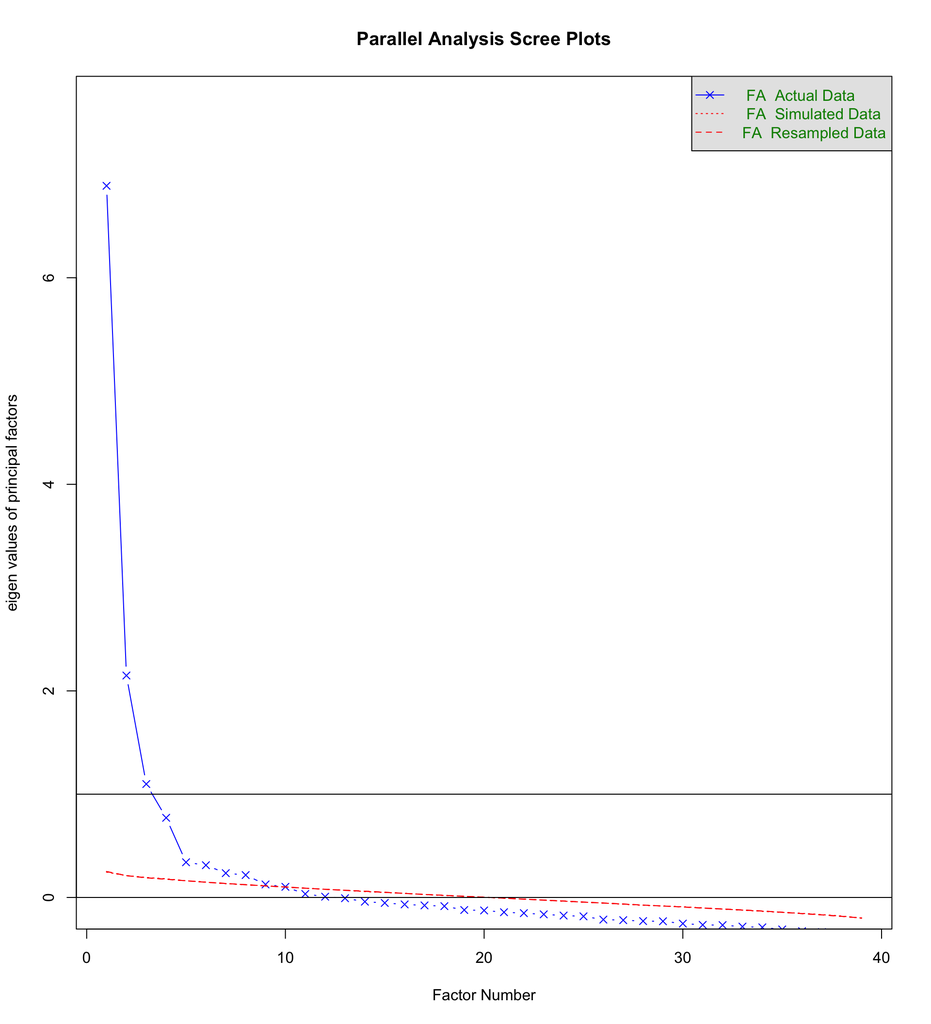

```
## Parallel analysis suggests that the number of factors =  10  and the number of components =  6
```

```r
# Plot Scree Plot
fa.parallel(fullScale, fm="minres", fa="fa", show.legend=TRUE) # yields 4 components
```

```r
faAll <- fa.poly(fullScale, nfactors = 4, rotate = "none")
print.psych(faAll, digits=2, cut=0.3)
```

```
## Factor Analysis using method =  minres
## Call: fa.poly(x = fullScale, nfactors = 4, rotate = "none")
## Standardized loadings (pattern matrix) based upon correlation matrix
##         MR1   MR2   MR3   MR4    h2   u2 com
## ps001  0.56                   0.379 0.62 1.5
## ps002       -0.33             0.214 0.79 2.6
## ps003  0.47                   0.346 0.65 2.2
## ps004  0.65                   0.549 0.45 1.6
## ps005  0.61 -0.44             0.586 0.41 1.9
## ps006  0.69 -0.43             0.701 0.30 1.8
## ps007  0.69 -0.44             0.705 0.30 1.9
## ps008  0.60                   0.403 0.60 1.2
## ps009             -0.41       0.228 0.77 1.7
## ps010       -0.33             0.228 0.77 2.6
## ps011  0.46                   0.266 0.73 1.5
## ps012  0.64                   0.419 0.58 1.1
## ps013                         0.044 0.96 1.3
## ps014  0.38  0.38             0.329 0.67 2.5
## ps015  0.38                   0.239 0.76 2.2
## ps016  0.60                   0.437 0.56 1.5
## ps017  0.30 -0.31             0.218 0.78 2.6
## ps018  0.38                   0.201 0.80 1.7
## ps019        0.35             0.206 0.79 2.2
## ps020  0.43                   0.324 0.68 2.6
## ps021                         0.133 0.87 2.7
## ps022  0.37                   0.187 0.81 1.7
## ps023  0.68                   0.560 0.44 1.4
## ps024  0.63                   0.489 0.51 1.5
## ps025  0.34              0.35 0.312 0.69 2.9
## ps026  0.65                   0.503 0.50 1.4
## ps027  0.66                   0.565 0.44 1.6
## ps028  0.40  0.33             0.317 0.68 2.6
## ps029  0.52  0.35             0.407 0.59 1.8
## ps030  0.54        0.31       0.406 0.59 1.7
## ps031                         0.166 0.83 3.0
## ps032  0.41  0.47       -0.37 0.524 0.48 2.9
## ps033  0.40        0.40 -0.31 0.488 0.51 3.6
## ps034  0.40                   0.304 0.70 2.8
## ps035  0.40        0.37       0.431 0.57 3.4
## ps036  0.53        0.42       0.454 0.55 1.9
```

[output cut: 17 more lines]

```
## The root mean square of the residuals (RMSR) is  0.03
## The df corrected root mean square of the residuals is  0.04
##
## The harmonic number of observations is  2766 with the empirical chi square  4403.29  with prob <  0
## The total number of observations was  2766  with MLE Chi Square =  5141.41  with prob <  0
##
## Tucker Lewis Index of factoring reliability =  0.851
## RMSEA index =  0.053  and the 90 % confidence intervals are  0.051 0.054
## BIC =  457.64
## Fit based upon off diagonal values = 0.98
## Measures of factor score adequacy
##                                                 MR1  MR2  MR3  MR4
## Correlation of scores with factors             0.97 0.92 0.84 0.81
## Multiple R square of scores with factors       0.95 0.85 0.71 0.66
## Minimum correlation of possible factor scores  0.89 0.70 0.42 0.33
```

# RESULTADOS

```r
# Remove items with low loadings
shortScale  <- fullScale[, -c(9,12,13,18,25)]
faShort   <-  fa.poly(shortScale, nfactors = 2, rotate = "oblimin", fm="minres")
print.psych(faShort, digits=2, cut=0.3)
```

```
## Factor Analysis using method =  minres
## Call: fa.poly(x = shortScale, nfactors = 2, rotate = "oblimin", fm = "minres")
## Standardized loadings (pattern matrix) based upon correlation matrix
##         MR2   MR1   h2   u2 com
## ps001        0.55 0.37 0.63 1.1
## ps002        0.45 0.17 0.83 1.3
## ps003        0.51 0.28 0.72 1.0
## ps004        0.64 0.50 0.50 1.1
## ps005        0.78 0.58 0.42 1.0
## ps006        0.81 0.67 0.33 1.0
## ps007        0.82 0.68 0.32 1.0
## ps008        0.49 0.38 0.62 1.4
## ps010        0.47 0.18 0.82 1.2
## ps011  0.32       0.20 0.80 1.7
## ps014  0.59       0.30 0.70 1.1
## ps015        0.48 0.22 0.78 1.0
## ps016  0.58       0.42 0.58 1.1
## ps017        0.47 0.19 0.81 1.1
## ps019  0.42       0.15 0.85 1.6
## ps020        0.42 0.20 0.80 1.1
## ps021  0.35       0.11 0.89 1.0
## ps022        0.38 0.16 0.84 1.1
## ps023  0.66       0.54 0.46 1.1
## ps024  0.53       0.41 0.59 1.3
## ps026  0.55       0.45 0.55 1.3
## ps027  0.66       0.52 0.48 1.1
## ps028  0.56       0.28 0.72 1.0
## ps029  0.65       0.41 0.59 1.0
## ps030        0.38 0.29 0.71 1.8
## ps031 -0.38       0.12 0.88 1.2
## ps032  0.65       0.36 0.64 1.1
## ps033  0.45       0.21 0.79 1.0
## ps034  0.43       0.20 0.80 1.0
## ps035  0.47       0.22 0.78 1.0
## ps036        0.33 0.27 0.73 1.9
## ps037  0.72       0.50 0.50 1.0
## ps038  0.57       0.30 0.70 1.0
## ps039  0.41       0.25 0.75 1.3
##
##                        MR2  MR1
```

[output cut: 17 more lines]

```
## The root mean square of the residuals (RMSR) is  0.05
## The df corrected root mean square of the residuals is  0.06
##
## The harmonic number of observations is  2766 with the empirical chi square  8832.51  with prob <  0
## The total number of observations was  2766  with MLE Chi Square =  7422.67  with prob <  0
##
## Tucker Lewis Index of factoring reliability =  0.769
## RMSEA index =  0.071  and the 90 % confidence intervals are  0.07 0.073
## BIC =  3507.64
## Fit based upon off diagonal values = 0.96
## Measures of factor score adequacy
##                                                 MR2  MR1
## Correlation of scores with factors             0.95 0.95
## Multiple R square of scores with factors       0.91 0.91
## Minimum correlation of possible factor scores  0.81 0.82
```

|  | MR2 | MR1 |
| --- | --- | --- |
| ps001 | 0.11 | 0.55 |
| ps002 | -0.17 | 0.45 |
| ps003 | 0.04 | 0.51 |
| ps004 | 0.14 | 0.64 |
| ps005 | -0.05 | 0.78 |
| ps006 | 0.01 | 0.81 |
| ps007 | -0.00 | 0.82 |
| ps008 | 0.22 | 0.49 |
| ps010 | -0.16 | 0.47 |
| ps011 | 0.32 | 0.20 |
| ps014 | 0.59 | -0.13 |
| ps015 | -0.03 | 0.48 |
| ps016 | 0.58 | 0.13 |
| ps017 | -0.11 | 0.47 |
| ps019 | 0.42 | -0.24 |
| ps020 | 0.07 | 0.42 |
| ps021 | 0.35 | -0.04 |
| ps022 | 0.06 | 0.38 |
| ps023 | 0.66 | 0.15 |
| ps024 | 0.53 | 0.20 |
| ps026 | 0.55 | 0.22 |
| ps027 | 0.66 | 0.12 |
| ps028 | 0.56 | -0.08 |
| ps029 | 0.65 | -0.02 |
| ps030 | 0.25 | 0.38 |
| ps031 | -0.38 | 0.11 |
| ps032 | 0.65 | -0.17 |
| ps033 | 0.45 | 0.01 |
| ps034 | 0.43 | 0.04 |
| ps035 | 0.47 | -0.00 |
| ps036 | 0.28 | 0.33 |
| ps037 | 0.72 | -0.03 |
| ps038 | 0.57 | -0.06 |
| ps039 | 0.41 | 0.16 |

#### Diagrama com fatores

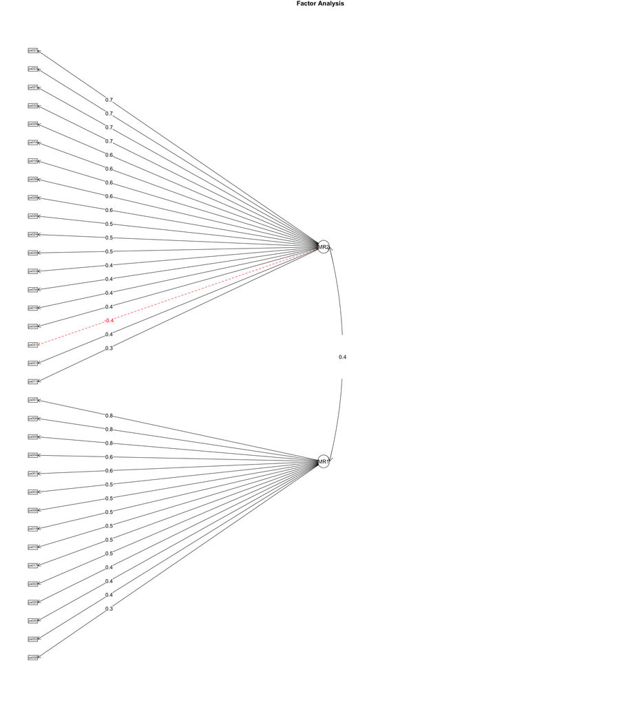

```r
fa.diagram(faShort)
```